# Extracting and analyzing data from Google Earth Engine using rgee

### Guelph’s temperature over time

How has Guelph’s temperature changed overtime since 2001? Here, I’ll extract Guelph’s monthly temperature for every month from 2001 to 2023.

Recall that we are working with an image collection. We’ll iterate through every month and year, and for each month, we will filter our collection to get all image for the month. Then, we will extract the mean temperature for the month by reducing all images in that sub collection. We will store our monthly mean data, as well as year and month in a feature collection.

This process is a but similar to a nested loop in R. We loop through each year, and through each month in a year.

```r
# The years and month that we will be iterating through
years <- ee$List$sequence(2001 , 2023)
months <- ee$List$sequence(01 , 12)

# let's extract the data
monthly.temp <- ee$FeatureCollection(years$map(ee_utils_pyfunc(function(year){
  return(months$map(ee_utils_pyfunc(function(month){

    monthly.img <- temp.gee$filter(ee$Filter$calendarRange(year, year, "year"))$
             filter(ee$Filter$calendarRange(month, month, "month"))$
             select('LST_Day_1km')$mean()

    monthly.temp <- monthly.img$clip(mask)$reduceRegion(reducer = ee$Reducer$mean())

    return(ee$Feature(NULL, list("month_temp" = monthly.temp$get("LST_Day_1km"),
                                 'year' = year,
                                 "month" = month)))

  })))
}))$flatten())
```

Again, I’ll export the output to Google Drive, download it, and load it in R

```r
#export the output to Google Drive
# By default, only properties that are non-NUll in the first image are exported. They might not include the output.
task <- ee_table_to_drive(
  collection = monthly.temp,
  description = "monthly_temp_mean_canada",
  folder = "GEE_imports",
  fileFormat = "CSV")

#task$start()
#ee_monitoring()

# Let's load our data and have a look a it
monthly.temp <- read.csv("monthly_temp_mean_Guelph.csv")
head(monthly.temp)
```

```
##   system.index month month_temp year                                   .geo
## 1            0     1   13318.57 2001 {"type":"MultiPoint","coordinates":[]}
## 2            1     2   13425.48 2001 {"type":"MultiPoint","coordinates":[]}
## 3            2     3   13550.12 2001 {"type":"MultiPoint","coordinates":[]}
## 4            3     4   14310.17 2001 {"type":"MultiPoint","coordinates":[]}
## 5            4     5   14703.12 2001 {"type":"MultiPoint","coordinates":[]}
## 6            5     6   14594.77 2001 {"type":"MultiPoint","coordinates":[]}
```

Now, we can plot our temperature data using ggplot. I’ll just do a bit of work first so we have a date for each data point, and to convert our measurements from Kelvin to Celcius

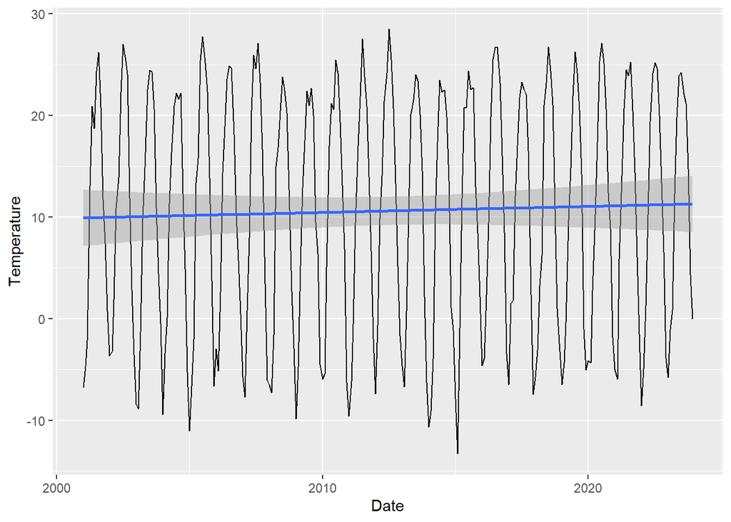

```r
# Add a column with dates (every monthly mean is set to the 1st of the month)
monthly.temp$Date <- anytime(paste0(monthly.temp$year, "-", monthly.temp$month))

# Convert from Kelvin to Celcius
monthly.temp$month_temp <- monthly.temp$month_temp*0.02- 273.15

# We create our plot
ggplot(data = monthly.temp, aes(y = month_temp, x = Date)) +
  geom_line()+
  geom_smooth(method='lm', formula= y~x)+
  labs(x = "Date", y = "Temperature")
```

We can also use the stl function (available in Base R) to decompose our time series into seasonal, trend and irregular components.

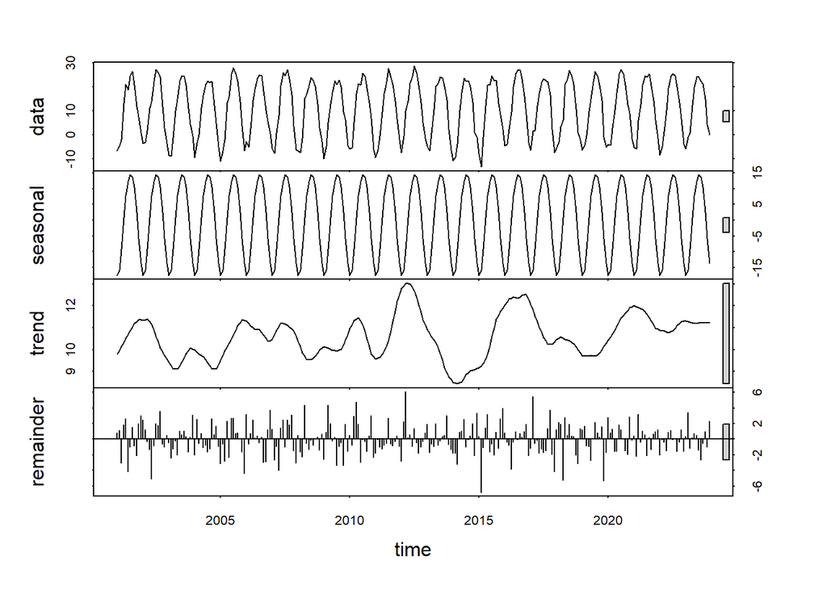

```r
temp.ts <- ts(data = monthly.temp$month_temp, start = c(2001, 1), end = c(2023,12), deltat = 1/12)
temp.comp <- stl(temp.ts, s.window = 'periodic')

plot(temp.comp)
```